# Project: Gapminder Environmental & Economic Data Analysis

- Introduction
- Data Wrangling
- Exploratory Data Analysis
- Conclusions

## Introduction

[Gapminder](https://www.gapminder.org/) has collected a lot of information about how people live their lives in different countries, tracked across the years, and on a number of different indicators.

Here we will explore Gapminder's country-level, annual data on carbon dioxide emissions per person (in metric tonnes), energy usage per person (in kg equivalent oil), and gross national income per person (in international dollars, fixed 2011 prices, PPP based on 2011 ICP), to discover any trends and correlations for these indicators.

We will focus on a time period for which data is available on all three indicators for the vast majority of countries, and we will focus on countries for which we have at least some data on each indicator during this period.

In particular we will seek to answer:

- how did the average values for these indicators change over the time period?
- which country achieved the greatest reduction (or smallest increase) in carbon dioxide emissions per person across the time period?
- is there a relationsip between gross national income per person and carbon dioxide emissions per person?
- did the relationship between energy use per person and carbon dioxide emissions per person change across the time period?

```python
import matplotlib.pyplot as plt
import matplotlib.colors
import numpy as np; np.random.seed(0)
import pandas as pd
import seaborn as sns
sns.set_theme()
%matplotlib inline
```

## Data Wrangling

### General Properties

```python
df_co2 = pd.read_csv('co2_emissions_tonnes_per_person.csv')
df_en = pd.read_csv('energy_use_per_person.csv')
df_gni = pd.read_csv('gnipercapita_ppp_current_international.csv')
df_pop = pd.read_csv('population_total.csv')
```

First we will check which countries and which years are covered by the datasets.

#### Carbon dioxide emissions per person

```python
df_co2.head()
```

|  | country | 1800 | 1801 | 1802 | 1803 | 1804 | 1805 | 1806 | 1807 | 1808 | ... | 2009 | 2010 | 2011 | 2012 | 2013 | 2014 | 2015 | 2016 | 2017 | 2018 |
| --- | --- | --- | --- | --- | --- | --- | --- | --- | --- | --- | --- | --- | --- | --- | --- | --- | --- | --- | --- | --- | --- |
| 0 | Afghanistan | NaN | NaN | NaN | NaN | NaN | NaN | NaN | NaN | NaN | ... | 0.238 | 0.29 | 0.406 | 0.345 | 0.28 | 0.253 | 0.262 | 0.245 | 0.247 | 0.254 |
| 1 | Albania | NaN | NaN | NaN | NaN | NaN | NaN | NaN | NaN | NaN | ... | 1.470 | 1.56 | 1.790 | 1.690 | 1.69 | 1.900 | 1.600 | 1.570 | 1.610 | 1.590 |
| 2 | Algeria | NaN | NaN | NaN | NaN | NaN | NaN | NaN | NaN | NaN | ... | 3.400 | 3.28 | 3.270 | 3.430 | 3.48 | 3.680 | 3.800 | 3.640 | 3.560 | 3.690 |
| 3 | Andorra | NaN | NaN | NaN | NaN | NaN | NaN | NaN | NaN | NaN | ... | 6.120 | 6.12 | 5.870 | 5.920 | 5.90 | 5.830 | 5.970 | 6.070 | 6.270 | 6.120 |
| 4 | Angola | NaN | NaN | NaN | NaN | NaN | NaN | NaN | NaN | NaN | ... | 1.230 | 1.24 | 1.250 | 1.350 | 1.28 | 1.640 | 1.220 | 1.180 | 1.140 | 1.120 |

5 rows × 220 columns

```python
df_co2.tail()
```

|  | country | 1800 | 1801 | 1802 | 1803 | 1804 | 1805 | 1806 | 1807 | 1808 | ... | 2009 | 2010 | 2011 | 2012 | 2013 | 2014 | 2015 | 2016 | 2017 | 2018 |
| --- | --- | --- | --- | --- | --- | --- | --- | --- | --- | --- | --- | --- | --- | --- | --- | --- | --- | --- | --- | --- | --- |
| 187 | Venezuela | NaN | NaN | NaN | NaN | NaN | NaN | NaN | NaN | NaN | ... | 6.430 | 6.670 | 5.900 | 6.510 | 6.140 | 6.130 | 5.690 | 5.470 | 5.230 | 4.810 |
| 188 | Vietnam | NaN | NaN | NaN | NaN | NaN | NaN | NaN | NaN | NaN | ... | 1.410 | 1.550 | 1.630 | 1.510 | 1.550 | 1.750 | 1.950 | 1.960 | 1.950 | 2.160 |
| 189 | Yemen | NaN | NaN | NaN | NaN | NaN | NaN | NaN | NaN | NaN | ... | 1.080 | 1.000 | 0.849 | 0.747 | 0.994 | 0.937 | 0.480 | 0.377 | 0.363 | 0.356 |
| 190 | Zambia | NaN | NaN | NaN | NaN | NaN | NaN | NaN | NaN | NaN | ... | 0.182 | 0.189 | 0.199 | 0.241 | 0.252 | 0.277 | 0.271 | 0.296 | 0.304 | 0.302 |
| 191 | Zimbabwe | NaN | NaN | NaN | NaN | NaN | NaN | NaN | NaN | NaN | ... | 0.441 | 0.607 | 0.737 | 0.587 | 0.872 | 0.881 | 0.881 | 0.771 | 0.845 | 0.850 |

5 rows × 220 columns

```python
df_co2.shape
```

```
(192, 220)
```

The carbon dixode emmissions dataset covers 192 countries between 1800 and 2018. There are no summary rows to be removed.

#### Energy usage per person

```python
df_en.head()
```

|  | country | 1960 | 1961 | 1962 | 1963 | 1964 | 1965 | 1966 | 1967 | 1968 | ... | 2006 | 2007 | 2008 | 2009 | 2010 | 2011 | 2012 | 2013 | 2014 | 2015 |
| --- | --- | --- | --- | --- | --- | --- | --- | --- | --- | --- | --- | --- | --- | --- | --- | --- | --- | --- | --- | --- | --- |
| 0 | Albania | NaN | NaN | NaN | NaN | NaN | NaN | NaN | NaN | NaN | ... | 707.0 | 680.0 | 711.0 | 732.0 | 729.0 | 765.0 | 688.0 | 801.0 | 808.0 | NaN |
| 1 | Algeria | NaN | NaN | NaN | NaN | NaN | NaN | NaN | NaN | NaN | ... | 1030.0 | 1080.0 | 1070.0 | 1150.0 | 1110.0 | 1140.0 | 1230.0 | 1250.0 | 1330.0 | NaN |
| 2 | Angola | NaN | NaN | NaN | NaN | NaN | NaN | NaN | NaN | NaN | ... | 459.0 | 472.0 | 492.0 | 515.0 | 521.0 | 522.0 | 552.0 | 534.0 | 545.0 | NaN |
| 3 | Antigua and Barbuda | NaN | NaN | NaN | NaN | NaN | NaN | NaN | NaN | NaN | ... | 1730.0 | 1740.0 | NaN | NaN | NaN | NaN | NaN | NaN | NaN | NaN |
| 4 | Argentina | NaN | NaN | NaN | NaN | NaN | NaN | NaN | NaN | NaN | ... | 1850.0 | 1860.0 | 1940.0 | 1870.0 | 1930.0 | 1950.0 | 1940.0 | 1970.0 | 2030.0 | NaN |

5 rows × 57 columns

```python
df_en.tail()
```

|  | country | 1960 | 1961 | 1962 | 1963 | 1964 | 1965 | 1966 | 1967 | 1968 | ... | 2006 | 2007 | 2008 | 2009 | 2010 | 2011 | 2012 | 2013 | 2014 | 2015 |
| --- | --- | --- | --- | --- | --- | --- | --- | --- | --- | --- | --- | --- | --- | --- | --- | --- | --- | --- | --- | --- | --- |
| 164 | Venezuela | NaN | NaN | NaN | NaN | NaN | NaN | NaN | NaN | NaN | ... | 2340.0 | 2130.0 | 2350.0 | 2320.0 | 2550.0 | 2330.0 | 2490.0 | 2310.0 | NaN | NaN |
| 165 | Vietnam | NaN | NaN | NaN | NaN | NaN | NaN | NaN | NaN | NaN | ... | 500.0 | 532.0 | 564.0 | 609.0 | 670.0 | 663.0 | 667.0 | 660.0 | NaN | NaN |
| 166 | Yemen | NaN | NaN | NaN | NaN | NaN | NaN | NaN | NaN | NaN | ... | 341.0 | 324.0 | 332.0 | 359.0 | 338.0 | 278.0 | 244.0 | 329.0 | NaN | NaN |
| 167 | Zambia | NaN | NaN | NaN | NaN | NaN | NaN | NaN | NaN | NaN | ... | 615.0 | 599.0 | 603.0 | 601.0 | 604.0 | 619.0 | 630.0 | 645.0 | NaN | NaN |
| 168 | Zimbabwe | NaN | NaN | NaN | NaN | NaN | NaN | NaN | NaN | NaN | ... | 810.0 | 787.0 | 724.0 | 729.0 | 745.0 | 795.0 | 824.0 | 845.0 | NaN | NaN |

5 rows × 57 columns

```python
df_en.shape
```

```
(169, 57)
```

The energy usage dataset covers 169 countries between 1960 and 2015. There are no summary rows to be removed.

#### Gross national income per person

```python
df_gni.head()
```

|  | country | 1990 | 1991 | 1992 | 1993 | 1994 | 1995 | 1996 | 1997 | 1998 | ... | 2010 | 2011 | 2012 | 2013 | 2014 | 2015 | 2016 | 2017 | 2018 | 2019 |
| --- | --- | --- | --- | --- | --- | --- | --- | --- | --- | --- | --- | --- | --- | --- | --- | --- | --- | --- | --- | --- | --- |
| 0 | Afghanistan | NaN | NaN | NaN | NaN | NaN | NaN | NaN | NaN | NaN | ... | 1710.0 | 1700.0 | 1920.0 | 2020.0 | 2070.0 | 2110.0 | 2150.0 | 2230.0 | 2260.0 | 2330.0 |
| 1 | Albania | 2550.0 | 1880.0 | 1740.0 | 2110.0 | 2300.0 | 2710.0 | 3050.0 | 2780.0 | 3110.0 | ... | 9540.0 | 10200.0 | 10500.0 | 10800.0 | 11400.0 | 11800.0 | 12200.0 | 13100.0 | 13800.0 | 14400.0 |
| 2 | Algeria | 6660.0 | 6510.0 | 6690.0 | 6630.0 | 6530.0 | 6710.0 | 6980.0 | 7120.0 | 7490.0 | ... | 13100.0 | 13400.0 | 13100.0 | 12800.0 | 12700.0 | 11700.0 | 11500.0 | 11400.0 | 11500.0 | 11500.0 |
| 3 | Angola | 2980.0 | 3300.0 | 1620.0 | 1490.0 | 1260.0 | 2340.0 | 2410.0 | 2820.0 | 2810.0 | ... | 5950.0 | 6130.0 | 6810.0 | 7130.0 | 7680.0 | 6960.0 | 6730.0 | 6860.0 | 6550.0 | 6390.0 |
| 4 | Antigua and Barbuda | 10500.0 | 11300.0 | 11600.0 | 12400.0 | 13200.0 | 12600.0 | 13500.0 | 14300.0 | 14900.0 | ... | 20100.0 | 19700.0 | 19000.0 | 18200.0 | 18100.0 | 17900.0 | 18400.0 | 18900.0 | 20500.0 | 21500.0 |

5 rows × 31 columns

```python
df_gni.tail()
```

|  | country | 1990 | 1991 | 1992 | 1993 | 1994 | 1995 | 1996 | 1997 | 1998 | ... | 2010 | 2011 | 2012 | 2013 | 2014 | 2015 | 2016 | 2017 | 2018 | 2019 |
| --- | --- | --- | --- | --- | --- | --- | --- | --- | --- | --- | --- | --- | --- | --- | --- | --- | --- | --- | --- | --- | --- |
| 181 | Venezuela | 9450.0 | 10500.0 | 11000.0 | 11000.0 | 10700.0 | 11200.0 | 11200.0 | 11800.0 | 11700.0 | ... | 16500.0 | 17100.0 | NaN | NaN | NaN | NaN | NaN | NaN | NaN | NaN |
| 182 | Vietnam | 860.0 | 930.0 | 1030.0 | 1120.0 | 1240.0 | 1380.0 | 1500.0 | 1630.0 | 1720.0 | ... | 4050.0 | 4330.0 | 4840.0 | 5130.0 | 5470.0 | 5790.0 | 6300.0 | 6620.0 | 7220.0 | 7750.0 |
| 183 | Yemen | 2060.0 | 2090.0 | 2220.0 | 2260.0 | 2350.0 | 2370.0 | 2320.0 | 2400.0 | 2590.0 | ... | 3920.0 | 3350.0 | 3340.0 | 3520.0 | NaN | NaN | NaN | NaN | NaN | NaN |
| 184 | Zambia | 1350.0 | 1320.0 | 1310.0 | 1430.0 | 1330.0 | 1360.0 | 1440.0 | 1480.0 | 1440.0 | ... | 2970.0 | 3160.0 | 3360.0 | 3430.0 | 3470.0 | 3360.0 | 3300.0 | 3330.0 | 3550.0 | 3580.0 |
| 185 | Zimbabwe | 1740.0 | 1850.0 | 1680.0 | 1710.0 | 1870.0 | 1890.0 | 2110.0 | 2170.0 | 2220.0 | ... | 1610.0 | 1800.0 | 2070.0 | 2310.0 | 2360.0 | 2410.0 | 2560.0 | 2760.0 | 2990.0 | 2730.0 |

5 rows × 31 columns

```python
df_gni.shape
```

```
(186, 31)
```

#### Population

```python
df_pop.head()
```

|  | country | 1800 | 1801 | 1802 | 1803 | 1804 | 1805 | 1806 | 1807 | 1808 | ... | 2091 | 2092 | 2093 | 2094 | 2095 | 2096 | 2097 | 2098 | 2099 | 2100 |
| --- | --- | --- | --- | --- | --- | --- | --- | --- | --- | --- | --- | --- | --- | --- | --- | --- | --- | --- | --- | --- | --- |
| 0 | Afghanistan | 3280000 | 3280000 | 3280000 | 3280000 | 3280000 | 3280000 | 3280000 | 3280000 | 3280000 | ... | 76600000 | 76400000 | 76300000 | 76100000 | 76000000 | 75800000 | 75600000 | 75400000 | 75200000 | 74900000 |
| 1 | Albania | 400000 | 402000 | 404000 | 405000 | 407000 | 409000 | 411000 | 413000 | 414000 | ... | 1330000 | 1300000 | 1270000 | 1250000 | 1220000 | 1190000 | 1170000 | 1140000 | 1110000 | 1090000 |
| 2 | Algeria | 2500000 | 2510000 | 2520000 | 2530000 | 2540000 | 2550000 | 2560000 | 2560000 | 2570000 | ... | 70400000 | 70500000 | 70500000 | 70600000 | 70700000 | 70700000 | 70700000 | 70700000 | 70700000 | 70700000 |
| 3 | Andorra | 2650 | 2650 | 2650 | 2650 | 2650 | 2650 | 2650 | 2650 | 2650 | ... | 63000 | 62900 | 62900 | 62800 | 62700 | 62700 | 62600 | 62500 | 62500 | 62400 |
| 4 | Angola | 1570000 | 1570000 | 1570000 | 1570000 | 1570000 | 1570000 | 1570000 | 1570000 | 1570000 | ... | 168000000 | 170000000 | 172000000 | 175000000 | 177000000 | 179000000 | 182000000 | 184000000 | 186000000 | 188000000 |

5 rows × 302 columns

```python
df_pop.tail()
```

|  | country | 1800 | 1801 | 1802 | 1803 | 1804 | 1805 | 1806 | 1807 | 1808 | ... | 2091 | 2092 | 2093 | 2094 | 2095 | 2096 | 2097 | 2098 | 2099 | 2100 |
| --- | --- | --- | --- | --- | --- | --- | --- | --- | --- | --- | --- | --- | --- | --- | --- | --- | --- | --- | --- | --- | --- |
| 190 | Venezuela | 1000000 | 978000 | 957000 | 936000 | 916000 | 896000 | 876000 | 857000 | 838000 | ... | 35500000 | 35400000 | 35200000 | 35100000 | 35000000 | 34800000 | 34700000 | 34500000 | 34400000 | 34200000 |
| 191 | Vietnam | 4000000 | 4100000 | 4200000 | 4310000 | 4410000 | 4530000 | 4640000 | 4750000 | 4870000 | ... | 100000000 | 100000000 | 99700000 | 99400000 | 99100000 | 98800000 | 98400000 | 98100000 | 97800000 | 97400000 |
| 192 | Yemen | 2590000 | 2590000 | 2590000 | 2590000 | 2590000 | 2590000 | 2590000 | 2590000 | 2590000 | ... | 54500000 | 54400000 | 54300000 | 54100000 | 54000000 | 53800000 | 53700000 | 53500000 | 53400000 | 53200000 |
| 193 | Zambia | 747000 | 758000 | 770000 | 782000 | 794000 | 806000 | 818000 | 831000 | 843000 | ... | 74400000 | 75200000 | 76000000 | 76800000 | 77600000 | 78400000 | 79200000 | 80000000 | 80800000 | 81500000 |
| 194 | Zimbabwe | 1090000 | 1090000 | 1090000 | 1090000 | 1090000 | 1090000 | 1090000 | 1090000 | 1090000 | ... | 30800000 | 30900000 | 30900000 | 30900000 | 30900000 | 30900000 | 31000000 | 31000000 | 31000000 | 31000000 |

5 rows × 302 columns

```python
df_pop.shape
```

```
(195, 302)
```

The population dataset covers 195 countries between 1800 and 2100. There are no summary rows to be removed.

### Merge & Reshape

As the datasets cover different time periods and a different number of countries, we will stack each dataset, and merge carbon dioxide emissions per person, energy usage per person, and gross national income per person using an outer join, so that we can get a sense of which time period we could analyse across all indicators, and get a sense of how much missing data there would be. We will merge this combined indicator dataset with the population dataset using a left join, as we're not interested in countries for which we only have population data.

#### Stack each dataset

```python
stack_co2 = df_co2.set_index(['country']).stack()
stack_co2.index.set_names('year', 1, inplace=True)
stack_co2.name = 'co2'
stack_co2.head()
```

```
country      year
Afghanistan  1949    0.00192
             1950    0.01090
             1951    0.01170
             1952    0.01150
             1953    0.01320
Name: co2, dtype: float64
```

```python
stack_en = df_en.set_index(['country']).stack()
stack_en.index.set_names('year', 1, inplace=True)
stack_en.name = 'en'
stack_en.head()
```

```
country  year
Albania  1971    785.0
         1972    866.0
         1973    763.0
         1974    777.0
         1975    827.0
Name: en, dtype: float64
```

```python
stack_gni = df_gni.set_index(['country']).stack()
stack_gni.index.set_names('year', 1, inplace=True)
stack_gni.name = 'gni'
stack_gni.head()
```

```
country      year
Afghanistan  2009    1520.0
             2010    1710.0
             2011    1700.0
             2012    1920.0
             2013    2020.0
Name: gni, dtype: float64
```

```python
stack_pop = df_pop.set_index(['country']).stack()
stack_pop.index.set_names('year', 1, inplace=True)
stack_pop.name = 'pop'
stack_pop.head()
```

```
country      year
Afghanistan  1800    3280000
             1801    3280000
             1802    3280000
             1803    3280000
             1804    3280000
Name: pop, dtype: int64
```

#### Merge the datasets

```python
df_all = (pd.merge(stack_co2, stack_en, how='outer', on=['country', 'year'])
        .merge(stack_gni, how='outer', on=['country', 'year'])
        .merge(stack_pop, how='left', on=['country', 'year']))
df_all.head()
```

| country | year | co2 | en | gni | pop |
| --- | --- | --- | --- | --- | --- |
| Afghanistan | 1949 | 0.00192 | NaN | NaN | 7620000 |
|  | 1950 | 0.01090 | NaN | NaN | 7750000 |
|  | 1951 | 0.01170 | NaN | NaN | 7840000 |
|  | 1952 | 0.01150 | NaN | NaN | 7940000 |
|  | 1953 | 0.01320 | NaN | NaN | 8040000 |

### Set scope of analysis

Now we can check to see how much data is missing from each dataset for each country and year, and set the scope of our analysis accordingly. We are aiming for a time period during which we have data for the vast majority of countries across all indicators, and countries for which we have at least some data on each indicator during this time period.

```python
df_all.info()
```

```
<class 'pandas.core.frame.DataFrame'>
MultiIndex: 18217 entries, ('Afghanistan', '1949') to ('Zimbabwe', '2019')
Data columns (total 4 columns):
 #   Column  Non-Null Count  Dtype
---  ------  --------------  -----
 0   co2     18039 non-null  float64
 1   en      5920 non-null   float64
 2   gni     5232 non-null   float64
 3   pop     18217 non-null  int64
dtypes: float64(3), int64(1)
memory usage: 658.8+ KB
```

We can see that we have population data wherever we have data on another indicator, so don't need to worry about missing population data. We will further investigate missing data for the other indicators.

First, we will find out how many countries are included in the combined data, and for which years we have data on the vast majority of them. We will accomplish this by reshaping the data to put the years in columns.

```python
df_stack = df_all.stack()
df_by_years = df_stack.unstack('year').reset_index()
df_by_years.rename(columns={'level_1':'indicator'}, inplace=True)
df_by_years.head()
```

| year | country | indicator | 1800 | 1801 | 1802 | 1803 | 1804 | 1805 | 1806 | 1807 | ... | 2010 | 2011 | 2012 | 2013 | 2014 | 2015 | 2016 | 2017 | 2018 | 2019 |
| --- | --- | --- | --- | --- | --- | --- | --- | --- | --- | --- | --- | --- | --- | --- | --- | --- | --- | --- | --- | --- | --- |
| 0 | Afghanistan | co2 | NaN | NaN | NaN | NaN | NaN | NaN | NaN | NaN | ... | 0.29 | 4.060000e-01 | 3.450000e-01 | 0.28 | 2.530000e-01 | 2.620000e-01 | 2.450000e-01 | 2.470000e-01 | 2.540000e-01 | NaN |
| 1 | Afghanistan | gni | NaN | NaN | NaN | NaN | NaN | NaN | NaN | NaN | ... | 1710.00 | 1.700000e+03 | 1.920000e+03 | 2020.00 | 2.070000e+03 | 2.110000e+03 | 2.150000e+03 | 2.230000e+03 | 2.260000e+03 | 2330.0 |
| 2 | Afghanistan | pop | NaN | NaN | NaN | NaN | NaN | NaN | NaN | NaN | ... | 29200000.00 | 3.010000e+07 | 3.120000e+07 | 32300000.00 | 3.340000e+07 | 3.440000e+07 | 3.540000e+07 | 3.630000e+07 | 3.720000e+07 | 38000000.0 |
| 3 | Albania | co2 | NaN | NaN | NaN | NaN | NaN | NaN | NaN | NaN | ... | 1.56 | 1.790000e+00 | 1.690000e+00 | 1.69 | 1.900000e+00 | 1.600000e+00 | 1.570000e+00 | 1.610000e+00 | 1.590000e+00 | NaN |
| 4 | Albania | en | NaN | NaN | NaN | NaN | NaN | NaN | NaN | NaN | ... | 729.00 | 7.650000e+02 | 6.880000e+02 | 801.00 | 8.080000e+02 | NaN | NaN | NaN | NaN | NaN |

5 rows × 222 columns

Next we filter out countries which are missing one or more indicators.

```python
keep = df_by_years['country'].value_counts()
keep = keep[keep == 4]
df_by_years_filtered = df_by_years[df_by_years['country'].isin(keep.index)]
df_by_years_filtered.head()
```

| year | country | indicator | 1800 | 1801 | 1802 | 1803 | 1804 | 1805 | 1806 | 1807 | ... | 2010 | 2011 | 2012 | 2013 | 2014 | 2015 | 2016 | 2017 | 2018 | 2019 |
| --- | --- | --- | --- | --- | --- | --- | --- | --- | --- | --- | --- | --- | --- | --- | --- | --- | --- | --- | --- | --- | --- |
| 3 | Albania | co2 | NaN | NaN | NaN | NaN | NaN | NaN | NaN | NaN | ... | 1.56 | 1.79 | 1.69 | 1.69 | 1.90 | 1.6 | 1.57 | 1.61 | 1.59 | NaN |
| 4 | Albania | en | NaN | NaN | NaN | NaN | NaN | NaN | NaN | NaN | ... | 729.00 | 765.00 | 688.00 | 801.00 | 808.00 | NaN | NaN | NaN | NaN | NaN |
| 5 | Albania | gni | NaN | NaN | NaN | NaN | NaN | NaN | NaN | NaN | ... | 9540.00 | 10200.00 | 10500.00 | 10800.00 | 11400.00 | 11800.0 | 12200.00 | 13100.00 | 13800.00 | 14400.0 |
| 6 | Albania | pop | NaN | NaN | NaN | NaN | NaN | NaN | NaN | NaN | ... | 2950000.00 | 2930000.00 | 2910000.00 | 2900000.00 | 2900000.00 | 2890000.0 | 2890000.00 | 2880000.00 | 2880000.00 | 2880000.0 |
| 7 | Algeria | co2 | NaN | NaN | NaN | NaN | NaN | NaN | NaN | NaN | ... | 3.28 | 3.27 | 3.43 | 3.48 | 3.68 | 3.8 | 3.64 | 3.56 | 3.69 | NaN |

5 rows × 222 columns

Now we will find out how many countries are included in the combined data.

```python
len(df_by_years_filtered['country'].unique())
```

```
166
```

We have 166 countries in the dataset.

Next, we will find out which years we have data on the vast majority of them, covering all indicitors.

```python
df_by_years_filtered.info(verbose=True, null_counts=True)
```

```
<class 'pandas.core.frame.DataFrame'>
Int64Index: 664 entries, 3 to 738
Data columns (total 222 columns):
 #   Column     Non-Null Count  Dtype
---  ------     --------------  -----
 0   country    664 non-null    object
 1   indicator  664 non-null    object
 2   1800       10 non-null     float64
 3   1801       10 non-null     float64
 4   1802       14 non-null     float64
 5   1803       10 non-null     float64
 6   1804       12 non-null     float64
 7   1805       10 non-null     float64
 8   1806       10 non-null     float64
 9   1807       12 non-null     float64
```

[output cut: 214 more lines]

As we have data for most indicators on the vast majority of countries from 1990 to 2014, we will focus analysis on these years.

```python
years = [str(x) for x in range(1990,2015)]
cols = ['country', 'indicator'] + years
df_scoped = df_by_years_filtered[cols]
df_scoped.head()
```

| year | country | indicator | 1990 | 1991 | 1992 | 1993 | 1994 | 1995 | 1996 | 1997 | ... | 2005 | 2006 | 2007 | 2008 | 2009 | 2010 | 2011 | 2012 | 2013 | 2014 |
| --- | --- | --- | --- | --- | --- | --- | --- | --- | --- | --- | --- | --- | --- | --- | --- | --- | --- | --- | --- | --- | --- |
| 3 | Albania | co2 | 1.68 | 1.31 | 0.775 | 0.731 | 0.612 | 0.67 | 0.651 | 0.498 | ... | 1.38 | 1.27 | 1.29 | 1.46 | 1.47 | 1.56 | 1.79 | 1.69 | 1.69 | 1.90 |
| 4 | Albania | en | 813.00 | 573.00 | 418.000 | 412.000 | 441.000 | 417.00 | 448.000 | 385.000 | ... | 720.00 | 707.00 | 680.00 | 711.00 | 732.00 | 729.00 | 765.00 | 688.00 | 801.00 | 808.00 |
| 5 | Albania | gni | 2550.00 | 1880.00 | 1740.000 | 2110.000 | 2300.000 | 2710.00 | 3050.000 | 2780.000 | ... | 5990.00 | 6750.00 | 7480.00 | 8260.00 | 8680.00 | 9540.00 | 10200.00 | 10500.00 | 10800.00 | 11400.00 |
| 6 | Albania | pop | 3290000.00 | 3280000.00 | 3250000.000 | 3200000.000 | 3150000.000 | 3110000.00 | 3100000.000 | 3100000.000 | ... | 3090000.00 | 3060000.00 | 3030000.00 | 3000000.00 | 2970000.00 | 2950000.00 | 2930000.00 | 2910000.00 | 2900000.00 | 2900000.00 |
| 7 | Algeria | co2 | 2.98 | 2.99 | 2.960 | 2.970 | 3.060 | 3.31 | 3.310 | 2.930 | ... | 3.21 | 2.98 | 3.18 | 3.14 | 3.40 | 3.28 | 3.27 | 3.43 | 3.48 | 3.68 |

5 rows × 27 columns

Next we check that within this shorter time period we still have at least one value per indicator for each country.

```python
df_scoped[years].sum(axis=1).isnull().sum()
```

```
0
```

We do!

### Analyse missing data

First, we wil find out how much missing data we need to deal with.

```python
missing = df_scoped[years].isnull().sum().sum()
missing
```

```
978
```

```python
not_missing = df_scoped[years].notnull().sum().sum()
not_missing
```

```
15622
```

```python
missing / (missing + not_missing)
```

```
0.05891566265060241
```

We are missing approximately 6% of datapoints.

Next, we will find out how each indicator changes from year to year, to assess potential options for filling missing data. We accomplish this by analysing the statistical properties of the distribution of year-on-year percentage changes for each indicator.

#### CO2 emissions per person

```python
df_co2_chg = df_scoped.query('indicator == "co2"')[years]
df_co2_chg = df_co2_chg.pct_change(axis=1).stack()
df_co2_chg.describe()
```

```
count    3963.000000
mean        0.031396
std         0.753328
min        -0.912594
25%        -0.032376
50%         0.009360
75%         0.057886
max        45.881720
dtype: float64
```

We plot a histogram of the distribution (after an initial plot, this was revised to ignore the extreme 1% of values, to give a clearer picture of the bulk of the distribution).

```python
df_co2_chg.quantile(0.005)
```

```
-0.3735049554684029
```

```python
df_co2_chg.quantile(0.995)
```

```
0.6080437367864712
```

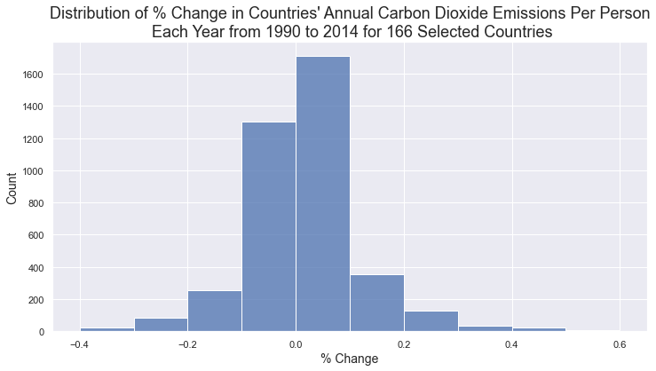

```python
df_co2_trim = df_co2_chg[(df_co2_chg > -0.38) & (df_co2_chg < 0.61)]
plt.figure(figsize=(12,6))
sns.histplot(df_co2_trim, bins=10, binrange=(-0.4, 0.6))
plt.title('Distribution of % Change in Countries\' Annual Carbon Dioxide Emissions Per Person\n Each Year from 1990 to 2014 for 166 Selected Countries', fontsize=18)
plt.xlabel('% Change', fontsize=14)
plt.ylabel('Count', fontsize=14);
```

```python
df_co2_chg.ge(2).sum()
```

```
3
```

Only 3 times - not often!

#### Energy usage per person

```python
df_en_chg = df_scoped.query('indicator == "en"')[years]
df_en_chg = df_en_chg.pct_change(axis=1).stack()
df_en_chg.describe()
```

```
count    3863.000000
mean        0.013297
std         0.157403
min        -0.694253
25%        -0.014493
50%         0.000000
75%         0.032323
max         5.924812
dtype: float64
```

We plot a histogram of the distribution ignoring the extreme 1% of values.

```python
df_en_chg.quantile(0.005)
```

```
-0.2665324597974985
```

```python
df_en_chg.quantile(0.995)
```

```
0.3947507523338838
```

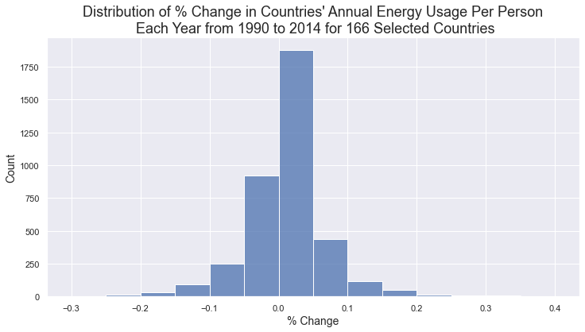

```python
df_en_trim = df_en_chg[(df_en_chg > -0.27) & (df_en_chg < 0.40)]
plt.figure(figsize=(12,6))
sns.histplot(df_en_trim, bins=14, binrange=(-0.3, 0.4))
plt.title('Distribution of % Change in Countries\' Annual Energy Usage Per Person\n Each Year from 1990 to 2014 for 166 Selected Countries', fontsize=18)
plt.xlabel('% Change', fontsize=14)
plt.ylabel('Count', fontsize=14);
```

```python
df_en_chg.ge(2).sum()
```

```
4
```

Only 4 times - not often!

#### Gross national income per person

```python
df_gni_chg = df_scoped.query('indicator == "gni"')[years]
df_gni_chg = df_gni_chg.pct_change(axis=1).stack()
df_gni_chg.describe()
```

```
count    3764.000000
mean        0.045901
std         0.078045
min        -0.615385
25%         0.017857
50%         0.044228
75%         0.072917
max         1.600000
dtype: float64
```

We plot a histogram of the distribution ignoring the extreme 1% of values.

```python
df_gni_chg.quantile(0.005)
```

```
-0.19574540954650013
```

```python
df_gni_chg.quantile(0.995)
```

```
0.34042203548085875
```

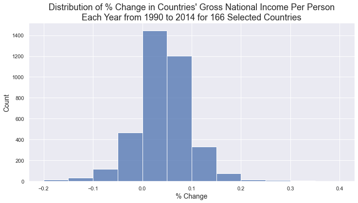

```python
df_gni_trim = df_gni_chg[(df_gni_chg > -0.2) & (df_gni_chg < 0.35)]
plt.figure(figsize=(12,6))
sns.histplot(df_gni_trim, bins=12, binrange=(-0.2, 0.4))
plt.title('Distribution of % Change in Countries\' Gross National Income Per Person\nEach Year from 1990 to 2014 for 166 Selected Countries', fontsize=18)
plt.xlabel('% Change', fontsize=14)
plt.ylabel('Count', fontsize=14);
```

Very low rate of change.

#### Summary

It is therefore judged reasonable, over the period of 24 years, to fill missing data by taking the next datapoint to the right (a following year), or taking the next datapoint to the left (a previous year) if this isn't available.

### Data Cleaning

We will fill missing data by taking the next datapoint to the right (a following year), or taking the next datapoint to the left (a previous year) if this isn't available.

```python
df = df_scoped
df.loc[:,years] = df.loc[:,years].fillna(method='backfill', axis=1)
df.loc[:,years] = df.loc[:,years].fillna(method='pad', axis=1)
df.head()
```

| year | country | indicator | 1990 | 1991 | 1992 | 1993 | 1994 | 1995 | 1996 | 1997 | ... | 2005 | 2006 | 2007 | 2008 | 2009 | 2010 | 2011 | 2012 | 2013 | 2014 |
| --- | --- | --- | --- | --- | --- | --- | --- | --- | --- | --- | --- | --- | --- | --- | --- | --- | --- | --- | --- | --- | --- |
| 3 | Albania | co2 | 1.68 | 1.31 | 0.775 | 0.731 | 0.612 | 0.67 | 0.651 | 0.498 | ... | 1.38 | 1.27 | 1.29 | 1.46 | 1.47 | 1.56 | 1.79 | 1.69 | 1.69 | 1.90 |
| 4 | Albania | en | 813.00 | 573.00 | 418.000 | 412.000 | 441.000 | 417.00 | 448.000 | 385.000 | ... | 720.00 | 707.00 | 680.00 | 711.00 | 732.00 | 729.00 | 765.00 | 688.00 | 801.00 | 808.00 |
| 5 | Albania | gni | 2550.00 | 1880.00 | 1740.000 | 2110.000 | 2300.000 | 2710.00 | 3050.000 | 2780.000 | ... | 5990.00 | 6750.00 | 7480.00 | 8260.00 | 8680.00 | 9540.00 | 10200.00 | 10500.00 | 10800.00 | 11400.00 |
| 6 | Albania | pop | 3290000.00 | 3280000.00 | 3250000.000 | 3200000.000 | 3150000.000 | 3110000.00 | 3100000.000 | 3100000.000 | ... | 3090000.00 | 3060000.00 | 3030000.00 | 3000000.00 | 2970000.00 | 2950000.00 | 2930000.00 | 2910000.00 | 2900000.00 | 2900000.00 |
| 7 | Algeria | co2 | 2.98 | 2.99 | 2.960 | 2.970 | 3.060 | 3.31 | 3.310 | 2.930 | ... | 3.21 | 2.98 | 3.18 | 3.14 | 3.40 | 3.28 | 3.27 | 3.43 | 3.48 | 3.68 |

5 rows × 27 columns

```python
df.info()
```

```
<class 'pandas.core.frame.DataFrame'>
Int64Index: 664 entries, 3 to 738
Data columns (total 27 columns):
 #   Column     Non-Null Count  Dtype
---  ------     --------------  -----
 0   country    664 non-null    object
 1   indicator  664 non-null    object
 2   1990       664 non-null    float64
 3   1991       664 non-null    float64
 4   1992       664 non-null    float64
 5   1993       664 non-null    float64
 6   1994       664 non-null    float64
 7   1995       664 non-null    float64
 8   1996       664 non-null    float64
 9   1997       664 non-null    float64
```

[output cut: 19 more lines]

```python
df.shape
```

```
(664, 27)
```

We now have a complete dataset to explore.

## Exploratory Data Analysis

### How did the average values for these indicators change between 1990 and 2014?

We will take weighted averages (using population as the weight) to establish the average values for each indicator for 1990 and 2014. Note that averages calculated pertain to those countries in our cleaned dataset, and not to the entire globe.

#### Carbon dioxide emissions per person

First, we reshape the data to enable calculating the weighted averages.

```python
df_co2_avg = df.query('indicator == "co2" | indicator == "pop"')
df_co2_avg = df_co2_avg.set_index(['country', 'indicator']).stack().unstack('indicator')
df_co2_avg.head()
```

| country | indicator year | co2 | pop |
| --- | --- | --- | --- |
| Albania | 1990 | 1.680 | 3290000.0 |
|  | 1991 | 1.310 | 3280000.0 |
|  | 1992 | 0.775 | 3250000.0 |
|  | 1993 | 0.731 | 3200000.0 |
|  | 1994 | 0.612 | 3150000.0 |

Next, we calculate the weighted averages.

```python
co2_avg = df_co2_avg.groupby('year').apply(lambda x: np.average(x['co2'], weights=x['pop']))
co2_avg
```

```
year
1990    4.251289
1991    4.186719
1992    4.077234
1993    4.063637
1994    4.028554
1995    4.055547
1996    4.124318
1997    4.088610
1998    4.006072
1999    3.997900
2000    4.065503
2001    4.046765
2002    4.091414
2003    4.239647
2004    4.375245
2005    4.471886
2006    4.560435
2007    4.640103
2008    4.684368
2009    4.570987
2010    4.760217
2011    4.865665
2012    4.886660
2013    4.857300
2014    4.837249
dtype: float64
```

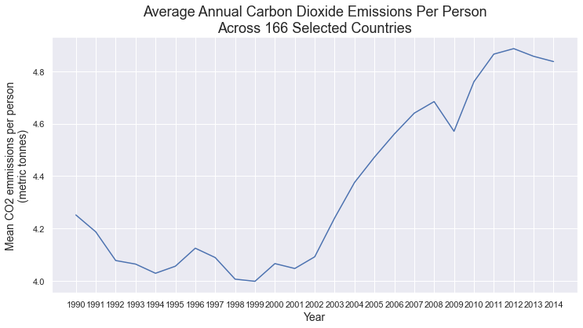

```python
plt.figure(figsize=(12,6))
sns.lineplot(data=co2_avg)
plt.title('Average Annual Carbon Dioxide Emissions Per Person\nAcross 166 Selected Countries', fontsize=18)
plt.xlabel('Year', fontsize=14)
plt.ylabel('Mean CO2 emmissions per person\n(metric tonnes)', fontsize=14);
```

Average annual carbon dioxide emmissions per person across the countries in our cleaned dataset increased from 4.25 metric tonnes in 1990 to 4.84 metric tonnes in 2014. Following an initial decline through the 90s, the majority of the growth occurred from 2002 to 2011, with a dip in 2009 (the global financial crisis).

#### Enery usage per person

First, we reshape the data to enable calculating the weighted averages.

```python
df_en_avg = df.query('indicator == "en" | indicator == "pop"')
df_en_avg = df_en_avg.set_index(['country', 'indicator']).stack().unstack('indicator')
df_en_avg.head()
```

| country | indicator year | en | pop |
| --- | --- | --- | --- |
| Albania | 1990 | 813.0 | 3290000.0 |
|  | 1991 | 573.0 | 3280000.0 |
|  | 1992 | 418.0 | 3250000.0 |
|  | 1993 | 412.0 | 3200000.0 |
|  | 1994 | 441.0 | 3150000.0 |

```python
en_avg = df_en_avg.groupby('year').apply(lambda x: np.average(x['en'], weights=x['pop']))
en_avg
```

```
year
1990    1649.589363
1991    1633.061577
1992    1606.110525
1993    1598.419834
1994    1584.060228
1995    1601.648677
1996    1619.130628
1997    1613.388438
1998    1595.845742
1999    1608.146782
2000    1623.555429
2001    1622.799973
2002    1635.551079
2003    1675.515919
2004    1730.363226
2005    1757.452410
2006    1787.919717
2007    1816.891390
2008    1818.336626
2009    1786.258131
2010    1865.067433
2011    1876.850069
2012    1891.124154
2013    1894.318816
2014    1893.340101
dtype: float64
```

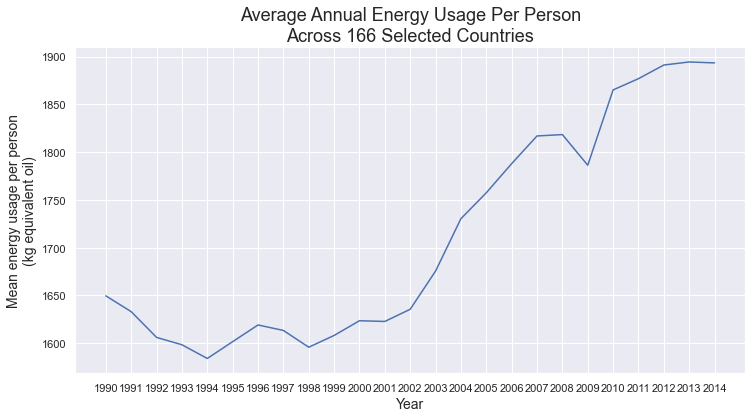

```python
plt.figure(figsize=(12,6))
sns.lineplot(data=en_avg)
plt.title('Average Annual Energy Usage Per Person\nAcross 166 Selected Countries', fontsize=18)
plt.xlabel('Year', fontsize=14)
plt.ylabel('Mean energy usage per person\n(kg equivalent oil)', fontsize=14);
```

Average annual energy usage per person across the countries in our cleaned dataset increased from 1650 kg equivalent oil in 1990 to 1893 kg equivalent oil in 2014. Following an initial decline through the early 90s, the majority of the growth occurred from 2002 to 2011, with a dip in 2009 (the global financial crisis).

#### Gross national income per person

First, we reshape the data to enable calculating the weighted averages.

```python
df_gni_avg = df.query('indicator == "gni" | indicator == "pop"')
df_gni_avg = df_gni_avg.set_index(['country', 'indicator']).stack().unstack('indicator')
df_gni_avg.head()
```

| country | indicator year | gni | pop |
| --- | --- | --- | --- |
| Albania | 1990 | 2550.0 | 3290000.0 |
|  | 1991 | 1880.0 | 3280000.0 |
|  | 1992 | 1740.0 | 3250000.0 |
|  | 1993 | 2110.0 | 3200000.0 |
|  | 1994 | 2300.0 | 3150000.0 |

```python
gni_avg = df_gni_avg.groupby('year').apply(lambda x: np.average(x['gni'], weights=x['pop']))
gni_avg
```

```
year
1990     5596.145693
1991     5804.819491
1992     5952.124576
1993     6112.658555
1994     6342.548262
1995     6597.121831
1996     6891.236514
1997     7202.160734
1998     7349.647940
1999     7601.900863
2000     8078.992520
2001     8370.432875
2002     8657.389444
2003     9026.286441
2004     9647.369044
2005    10266.740960
2006    11153.269560
2007    11919.195576
2008    12448.029261
2009    12412.346242
2010    13101.877015
2011    13824.132054
2012    14431.129602
2013    14936.619940
2014    15366.195138
dtype: float64
```

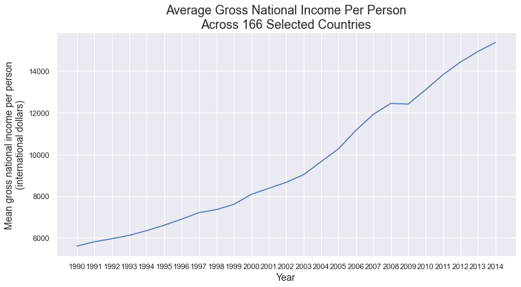

```python
plt.figure(figsize=(12,6))
sns.lineplot(data=gni_avg)
plt.title('Average Gross National Income Per Person\nAcross 166 Selected Countries', fontsize=18)
plt.xlabel('Year', fontsize=14)
plt.ylabel('Mean gross national income per person\n(international dollars)', fontsize=14);
```

Average gross national income per person across the countries in our cleaned dataset increased from 5596 international dollars in 1990 to 15366 international dollars in 2014. The growth accelerated before pausing in 2009 (the global financial crisis), and then resumed at constant pace.

### Which country achieved the greatest reduction (or smallest increase) in carbon dioxide emissions per person across the time period?

First we calculate the change in all indicators from 1990 to 2014 for each country, and then find the minimum value for change in carbon dioxide emissions per person.

```python
df_ch = df.set_index(['country', 'indicator'])[['1990', '2014']]
df_ch['change'] = df_ch['2014'] - df_ch['1990']
df_ch['pct_change'] = 100 * df_ch['change'] / df_ch['1990']
df_ch['change'].groupby('indicator').min()
```

```
indicator
co2        -13.4
en       -3550.0
gni     -29300.0
pop   -6400000.0
Name: change, dtype: float64
```

Then we find which country was associated with this change.

```python
df_ch.query('indicator == "co2" & change <= -13.4')
```

| country | year indicator | 1990 | 2014 | change | pct_change |
| --- | --- | --- | --- | --- | --- |
| Luxembourg | co2 | 31.1 | 17.7 | -13.4 | -43.086817 |

Finally, we check how the other indicators changed for this country, to provide additional insight.

```python
df_ch.query('country == "Luxembourg"')
```

| country | year indicator | 1990 | 2014 | change | pct_change |
| --- | --- | --- | --- | --- | --- |
| Luxembourg | co2 | 31.1 | 17.7 | -13.4 | -43.086817 |
|  | en | 8870.0 | 6860.0 | -2010.0 | -22.660654 |
|  | gni | 28700.0 | 67300.0 | 38600.0 | 134.494774 |
|  | pop | 382000.0 | 555000.0 | 173000.0 | 45.287958 |

Luxembourg achieved the greatest reduction in carbon dioxide emissions per person between 1990 and 2014, reducing emissions from 31.1 metric tonnes per person to 17.7 metric tons per person - a 43.1% reduction.

The energy usage per person also dropped by 22.7%, and the population increased by 45.3%.

It seems the increase in population was handled with more efficient energy usage, alongside increased usage of clean energy.

### Is there a relationsip between gross national income per person and carbon dioxide emissions per person?

First, we reshape the data to facilitate a scatter plot of gross national income per person vs carbon dioxide emissions per person.

```python
df_by_ind = df.set_index(['country', 'indicator']).stack()
df_by_ind = df_by_ind.unstack('indicator')
df_by_ind.head()
```

| country | indicator year | co2 | en | gni | pop |
| --- | --- | --- | --- | --- | --- |
| Albania | 1990 | 1.680 | 813.0 | 2550.0 | 3290000.0 |
|  | 1991 | 1.310 | 573.0 | 1880.0 | 3280000.0 |
|  | 1992 | 0.775 | 418.0 | 1740.0 | 3250000.0 |
|  | 1993 | 0.731 | 412.0 | 2110.0 | 3200000.0 |
|  | 1994 | 0.612 | 441.0 | 2300.0 | 3150000.0 |

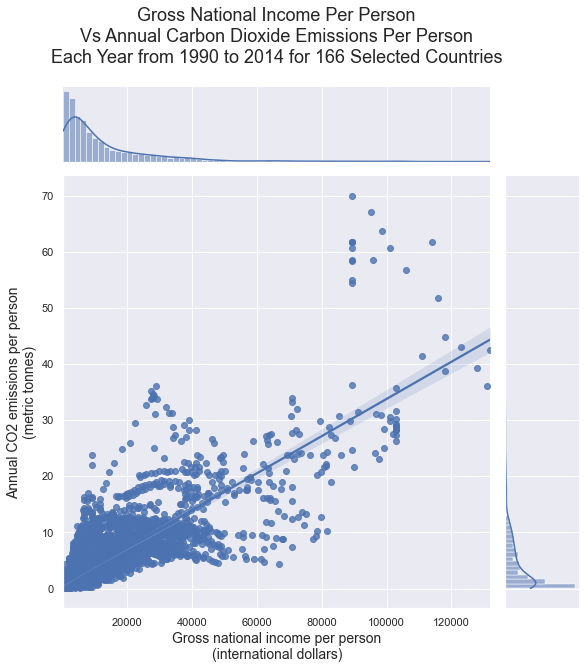

```python
sns.jointplot(x='gni', y='co2', data=df_by_ind, kind='reg', height=8)
plt.title('Gross National Income Per Person\nVs Annual Carbon Dioxide Emissions Per Person' +
              '\nEach Year from 1990 to 2014 for 166 Selected Countries', y=1.25, fontsize=18)
plt.xlabel('Gross national income per person\n(international dollars)', fontsize=14)
plt.ylabel('Annual CO2 emissions per person\n(metric tonnes)', fontsize=14);
```

There does appear to be a positive correlation, but looking at the regression, the residual variance appears to increase with predicted value, and the distributions of both indicators are right skewed, so we take logs of the indicators.

```python
df_by_ind[['co2_log', 'en_log', 'gni_log']] = np.log(df_by_ind[['co2', 'en', 'gni']])
df_by_ind.head()
```

| country | indicator year | co2 | en | gni | pop | co2_log | en_log | gni_log |
| --- | --- | --- | --- | --- | --- | --- | --- | --- |
| Albania | 1990 | 1.680 | 813.0 | 2550.0 | 3290000.0 | 0.518794 | 6.700731 | 7.843849 |
|  | 1991 | 1.310 | 573.0 | 1880.0 | 3280000.0 | 0.270027 | 6.350886 | 7.539027 |
|  | 1992 | 0.775 | 418.0 | 1740.0 | 3250000.0 | -0.254892 | 6.035481 | 7.461640 |
|  | 1993 | 0.731 | 412.0 | 2110.0 | 3200000.0 | -0.313342 | 6.021023 | 7.654443 |
|  | 1994 | 0.612 | 441.0 | 2300.0 | 3150000.0 | -0.491023 | 6.089045 | 7.740664 |

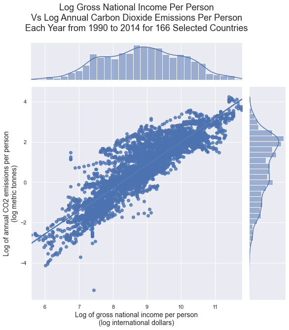

```python
sns.jointplot(x='gni_log', y='co2_log', data=df_by_ind,
                  kind='reg', height=8);
plt.title('Log Gross National Income Per Person\nVs Log Annual Carbon Dioxide Emissions Per Person' +
              '\nEach Year from 1990 to 2014 for 166 Selected Countries', y=1.25, fontsize=18)
plt.xlabel('Log of gross national income per person\n(log international dollars)', fontsize=14)
plt.ylabel('Log of annual CO2 emissions per person\n(log metric tonnes)', fontsize=14);
```

Now we can see a strong, positive correlation - as gross national income per person increases, carbon dioxide emissions per person increase.

### Did the relationship between energy use per person and carbon dioxide emissions per person change across the time period?

First, we take subset of the data (first and last years) and reset the index to facilitate a comparison of regression lines for each year on a single plot.

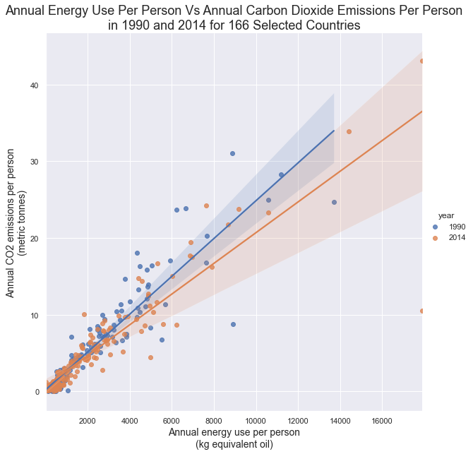

```python
df_by_ind[['co2_sqrt', 'en_sqrt', 'gni_sqrt']] = np.sqrt(df_by_ind[['co2', 'en', 'gni']])
df_comp = df_by_ind.query('year == "1990" | year == "2014"').reset_index()

sns.lmplot(x='en', y='co2', data=df_comp, hue='year', height=8);
plt.title('Annual Energy Use Per Person Vs Annual Carbon Dioxide Emissions Per Person' +
              '\nin 1990 and 2014 for 166 Selected Countries', fontsize=18)
plt.xlabel('Annual energy use per person\n(kg equivalent oil)', fontsize=14)
plt.ylabel('Annual CO2 emissions per person\n(metric tonnes)', fontsize=14);
```

It does seem likely that the relationship between energy use per person and carbon dioxide emissions has changed across the time period, however, note that the confidence intervals of the two regression lines overlap, so it is possible that there is no change in the relationship.

As residual variance is not constant, we take logs of the indicators again.

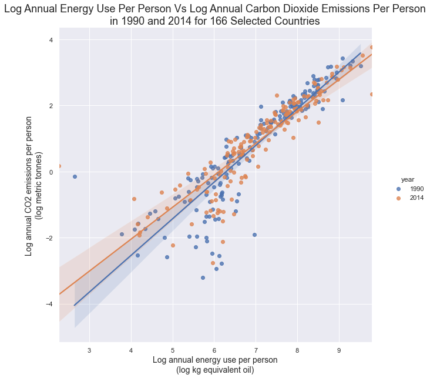

```python
sns.lmplot(x='en_log', y='co2_log', data=df_comp, hue='year', height=8);
plt.title('Log Annual Energy Use Per Person Vs Log Annual Carbon Dioxide Emissions Per Person' +
              '\nin 1990 and 2014 for 166 Selected Countries', fontsize=18)
plt.xlabel('Log annual energy use per person\n(log kg equivalent oil)', fontsize=14)
plt.ylabel('Log annual CO2 emissions per person\n(log metric tonnes)', fontsize=14);
```

This time the log transformation seems too strong, so we try a square root transformation.

```python
df_by_ind[['co2_sqrt', 'en_sqrt', 'gni_sqrt']] = np.sqrt(df_by_ind[['co2', 'en', 'gni']])
df_by_ind.head()
```

| country | indicator year | co2 | en | gni | pop | co2_log | en_log | gni_log | co2_sqrt | en_sqrt | gni_sqrt |
| --- | --- | --- | --- | --- | --- | --- | --- | --- | --- | --- | --- |
| Albania | 1990 | 1.680 | 813.0 | 2550.0 | 3290000.0 | 0.518794 | 6.700731 | 7.843849 | 1.296148 | 28.513155 | 50.497525 |
|  | 1991 | 1.310 | 573.0 | 1880.0 | 3280000.0 | 0.270027 | 6.350886 | 7.539027 | 1.144552 | 23.937418 | 43.358967 |
|  | 1992 | 0.775 | 418.0 | 1740.0 | 3250000.0 | -0.254892 | 6.035481 | 7.461640 | 0.880341 | 20.445048 | 41.713307 |
|  | 1993 | 0.731 | 412.0 | 2110.0 | 3200000.0 | -0.313342 | 6.021023 | 7.654443 | 0.854985 | 20.297783 | 45.934736 |
|  | 1994 | 0.612 | 441.0 | 2300.0 | 3150000.0 | -0.491023 | 6.089045 | 7.740664 | 0.782304 | 21.000000 | 47.958315 |

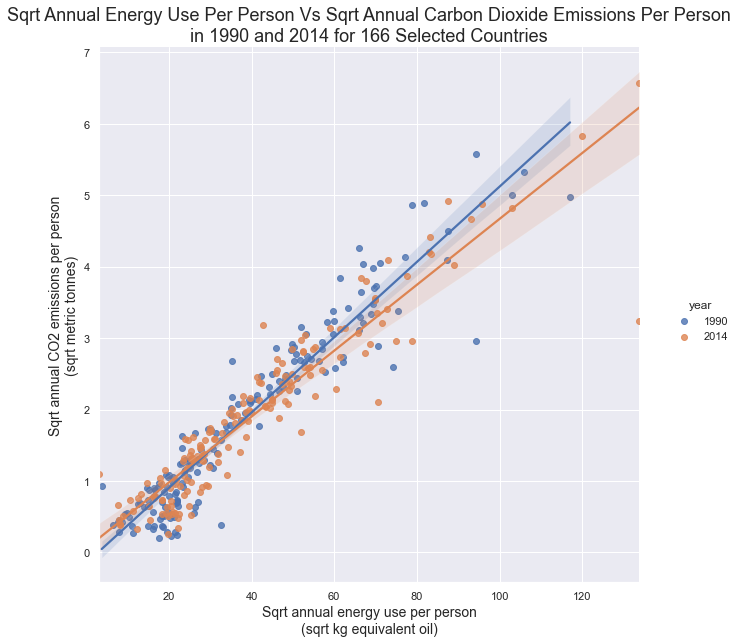

```python
df_comp = df_by_ind.query('year == "1990" | year == "2014"').reset_index()

sns.lmplot(x='en_sqrt', y='co2_sqrt', data=df_comp, hue='year', height=8);
plt.title('Sqrt Annual Energy Use Per Person Vs Sqrt Annual Carbon Dioxide Emissions Per Person' +
              '\nin 1990 and 2014 for 166 Selected Countries', fontsize=18)
plt.xlabel('Sqrt annual energy use per person\n(sqrt kg equivalent oil)', fontsize=14)
plt.ylabel('Sqrt annual CO2 emissions per person\n(sqrt metric tonnes)', fontsize=14);
```

Here, the residual variance now seems closer to constant. The transformation doesn't add much insight to whether the relationship has changed, however it does more clearly show that at low energy usage per person, the CO2 emissions per person may have increased, while at high energy usage per person, the CO2 emissions per person may have decreased.

## Conclusions

### Limitations

Conclusions drawn here are based on analysis of 166 countries for which we had data on the indicators during the period 1990-2014.

### How did the average values for these indicators change over the time period?

Average annual carbon dioxide emmissions per person across the countries in our cleaned dataset increased from 4.25 metric tonnes in 1990 to 4.84 metric tonnes in 2014. Following an initial decline through the 90s, the majority of the growth occurred from 2002 to 2011, with a dip in 2009 (the global financial crisis).

Average annual energy usage per person across the countries in our cleaned dataset increased from 1650 kg equivalent oil in 1990 to 1893 kg equivalent oil in 2014. Following an initial decline through the early 90s, the majority of the growth occurred from 2002 to 2011, with a dip in 2009 (the global financial crisis).

Average gross national income per person across the countries in our cleaned dataset increased from 5596 international dollars in 1990 to 15366 international dollars in 2014. The growth accelerated before pausing in 2009 (the global financial crisis), and then resumed at constant pace.

### Which country achieved the greatest reduction (or smallest increase) in carbon dioxide emissions per person across the time period?

Luxembourg achieved the greatest reduction in CO2 emissions per person between 1990 and 2014, reducing emissions from 31.1 metric tonnes per person to 17.7 metric tons per person - a 43.1% reduction.

The energy usage per person also dropped by 22.7%, and the population increased by 45.3%.

It seems the increase in population was handled with more efficient energy usage, alongside increased usage of clean energy.

### Is there a relationsip between gross national income per person and carbon dioxide emissions per person?

There is a strong, positive correlation - as gross national income per person increases, carbon dioxide emissions per person increase.

### Did the relationship between energy use per person and carbon dioxide emissions per person change across the time period?

It does seem likely that the relationship between energy use per person and carbon dioxide emissions has changed across the time period, however, note that the confidence intervals of the two regression lines overlap, so it is possible that there is no change in the relationship.

At low energy usage per person, the CO2 emissions per person may have increased, while at high energy usage per person, the CO2 emissions per person may have decreased.